# Composite panel benchmark

Combine fixed effects, factors, time-series paths, and sparse donor structure in one stress test.

The composite family is a package benchmark. It is not a reproduction of a published paper. Its purpose is to test an estimator when several familiar untreated-outcome structures are present at once.

## 1 Outcome decomposition

The untreated outcome is a weighted sum of four components:

$$Y(0)
=w_FY_F+w_TY_T+w_SY_S+w_AY_A+\varepsilon,$$

where $Y_F$ is a low-rank factor component, $Y_T$ is a persistent time-series component, $Y_S$ has sparse synthetic-control donor structure, and $Y_A$ is an additive two-way fixed-effects component.

The weights are explicit configuration fields. They need not sum to one, but a sum of one makes their relative scale easier to interpret.

```python
import matplotlib.pyplot as plt
import numpy as np

from pypanelsim import designs

config = designs.GSynthCompositeConfig(
    n_control=160,
    n_treated=40,
    n_pre=40,
    n_post=10,
    factor_weight=0.25,
    time_series_weight=0.25,
    synthetic_weight=0.25,
    fixed_effect_weight=0.25,
    factor_rank=2,
    ar_coefficient=0.5,
    effect_slope=0.2,
    noise_scale=0.6,
)

panel = designs.gsynth_composite(config=config, seed=42)
print(panel.shape)
print(round(panel.true_att, 3))
```

```
(200, 50)
1.1
```

## 2 Check component metadata

```python
outcome_metadata = panel.metadata["outcome"]
print(outcome_metadata["model"])
print(outcome_metadata.keys())
```

```
SumOutcomeModel
dict_keys(['model', 'kind', 'components'])
```

The sum model stores each component’s output in metadata, so the experiment can check which structures were active.

## 3 Vary one component at a time

Use ablations before interpreting a result from the full mixture.

```python
factor_only = designs.GSynthCompositeConfig(
    n_control=80,
    n_treated=20,
    factor_weight=1.0,
    time_series_weight=0.0,
    synthetic_weight=0.0,
    fixed_effect_weight=0.0,
)

fixed_effect_only = designs.GSynthCompositeConfig(
    n_control=80,
    n_treated=20,
    factor_weight=0.0,
    time_series_weight=0.0,
    synthetic_weight=0.0,
    fixed_effect_weight=1.0,
)

factor_panel = designs.gsynth_composite(config=factor_only, seed=17)
fixed_effect_panel = designs.gsynth_composite(
    config=fixed_effect_only,
    seed=17,
)

print(factor_panel.shape, fixed_effect_panel.shape)
```

```
(100, 50) (100, 50)
```

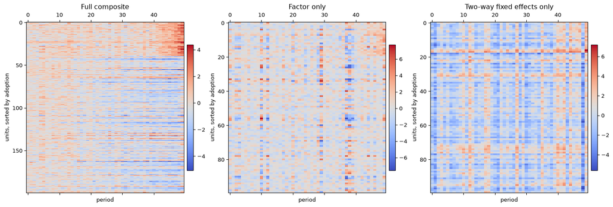

Figure 1: Observed outcomes for the full composite benchmark and two single-component ablations.

```python
ablation_panels = (
    ("Full composite", panel),
    ("Factor only", factor_panel),
    ("Two-way fixed effects only", fixed_effect_panel),
)
figure, axes = plt.subplots(1, 3, figsize=(15, 5), constrained_layout=True)
for axis, (label, draw) in zip(axes, ablation_panels, strict=True):
    order = np.argsort(draw.adoption_times, kind="stable")
    image = axis.matshow(draw.outcome[order], aspect="auto", cmap="coolwarm")
    axis.set_title(label)
    axis.set_xlabel("period")
    axis.set_ylabel("units, sorted by adoption")
    figure.colorbar(image, ax=axis, fraction=0.04, pad=0.02)
plt.show()
```

An estimator that fails only in the full mixture may be sensitive to interactions among structures. An estimator that fails in a single-component ablation has a more specific problem.

## 4 Why this is not the first benchmark

A composite design is useful only after simpler cases have been checked. Start with the canonical designs, then add one complication at a time:

1. two-way fixed effects;
2. one strong factor;
3. treated-control loading separation;
4. time-series persistence;
5. sparse donor structure;
6. the full composite.

## 5 Naming and claims

The constructor retains the historical name `gsynth_composite` for API compatibility. The name does not mean that it reproduces a particular generalized synthetic-control implementation. Reports should call it the “pypanelsim composite benchmark” and list the component weights.